# riojaPlot: User Guide (Version 0.1-21)

### 15. How do I add my own zones to a diagram?

Arbitrary zones can be added using function `addRPZone`, as either single lines, or as shaded rectangles. Simply save the riojaPlot object and pass it to `addRPZone`.

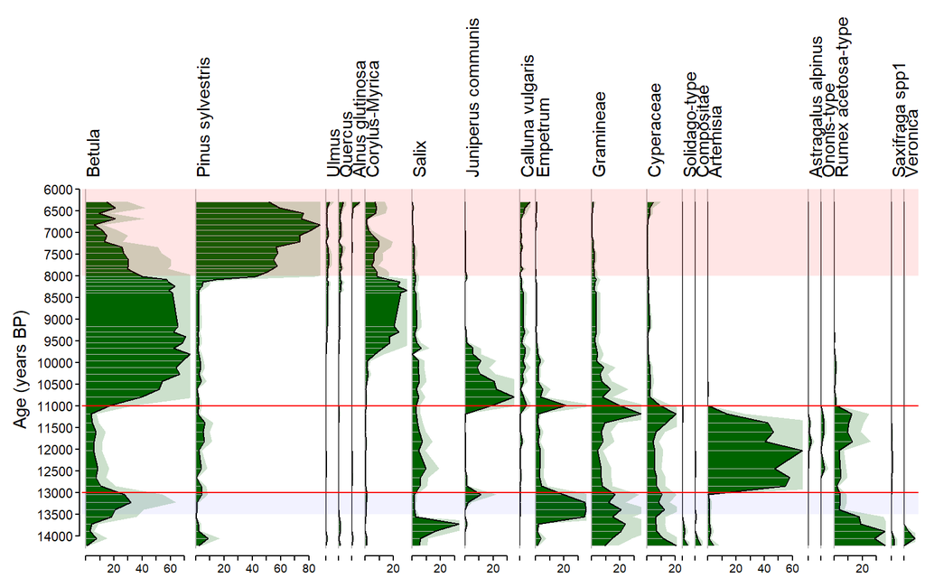

```r
mx <- apply(aber.poll, 2, max)
aber.sel <- names(mx[mx > 2])

rp <- riojaPlot(aber.poll, aber.chron, aber.sel,
   yvar.name="Age (years BP)",
   ymin=6000,
   ymax=14300,
   yinterval=500,
   scale.percent=TRUE,
   plot.exag=TRUE)

# define zone lines at 11000 and 13000 years BP
myzones <- c(11000, 13000)
addRPZone(rp, myzones, col="red")

# add shaded zone from 6000 to 8000 years BP
addRPZone(rp, 6000, 8000)

# change colour and shading
addRPZone(rp, 13000, 13500, col="blue", alpha = 0.05)
```

```
#> [1]     0     1 14300  6000
```

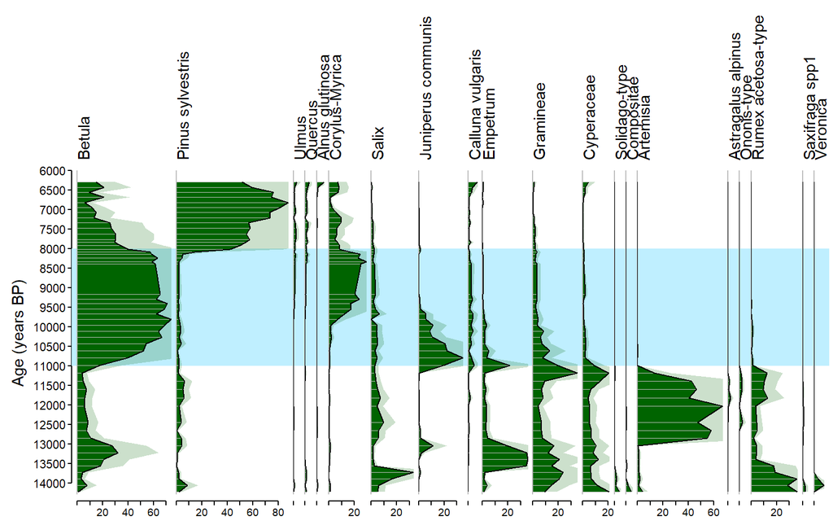

```r
# The zones above are plotted over the existing diagram.
# It is possible to plot zones or other annotations behind
# the diagram using a custom function supplied to style fun.plotback
# this takes 2 arguments, usr = vector of 4 numbers giving the
# coordinates of the plotting area in data units (x is 0-1)
# and fig,coordinates of the plotting area as fractions of the page size

fun.back <- function(usr, fig, style) {
  print(usr)
  rect(0, 8000, 1, 11000, col="lightblue1", border=NA)
}

rp <- riojaPlot(aber.poll, aber.chron, aber.sel,
   yvar.name="Age (years BP)",
   ymin=6000,
   ymax=14300,
   yinterval=500,
   scale.percent=TRUE,
   plot.exag=TRUE,
   fun.plotback=fun.back
   )
```

### 16. How do I include special symbols in the variable names

We can pass a character vector of custom names for each column using style `xlabels` and use `expression` to create names with superscripts, subscripts or greek letters.

```r
nms <- colnames(maule.data)
nms[8] <- expression(delta^15*N)
```

We can also use function `label_geochem` in package `tidypaleo` to automatically add annotations for a slected range of common geochemical variables.

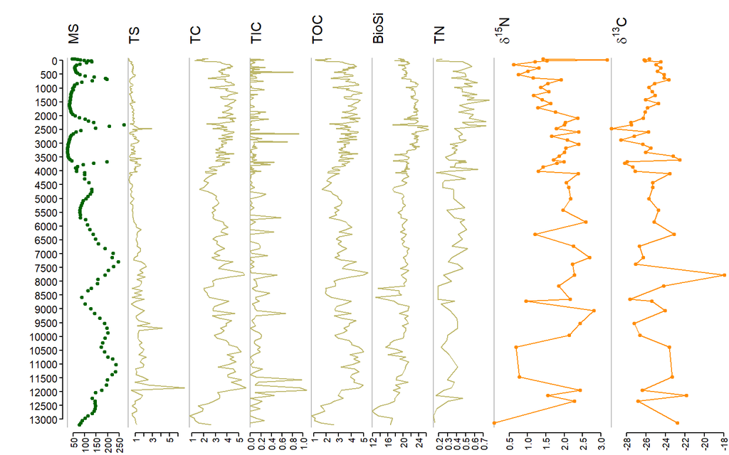

```r
library(tidypaleo)
nms <- colnames(maule.data)
nms2 <- as.expression(sapply(nms, function(x) unlist(label_geochem(x)[[1]])))
riojaPlot(maule.data, maule.chron, groups=groups,
          yvar.name="age_BP",
          xlabels=nms2,
          ymin=-100,
          ymax=13300,
          yinterval=500,
          plot.bar=FALSE,
          plot.poly=FALSE,
          plot.line=selline,
          plot.symb=selsymb,
          plot.groups=TRUE,
          ylabPos=2.2,
          symb.cex=0.5,
          ytks1=myticks,
          las.xaxis=2,
          graph.widths=widths,
          yBottom=0.06
          )
```

### 17. What is the best way to save riojaPlot diagrams?

``riojaPlot` figures can be saved to file or copied to the clipboard from R or RStudio. This will work but will not always give the best diagram because the plot is scaled to the window it is drawn in, and saving a plot that is already drawn to a different size or aspect ratio may result in unexpected gaps between axes or truncated text. To avoid this, place device calls around the plot to explicity draw the figure to a graphics file. For a stand-alone figure `pdf` is appropriate. For a figure to include in a document or presentation `svg` will usually work best for embedding in recent MS Office documents, or `png` for earlier documents. Just be careful that if you get an error during the plot to remember to call `dev.off()` to return plotting to the screen.

```r
svg("Myplot1.svg", width=10, height=6) # figure dimensions in inches
# or pdf("Myplot.pdf", width=10, height=6) for output to a pdf file
riojaPlot(aber.poll, aber.chron, aber.sel,
   yvar.name="Age (years BP)",
   ymin=6000,
   ymax=14300,
   yinterval=500,
   scale.percent=TRUE,
   plot.exag=TRUE,
   )
dev.off()
```

To view a saved svg or pdf file use `cowplot::draw_image`.

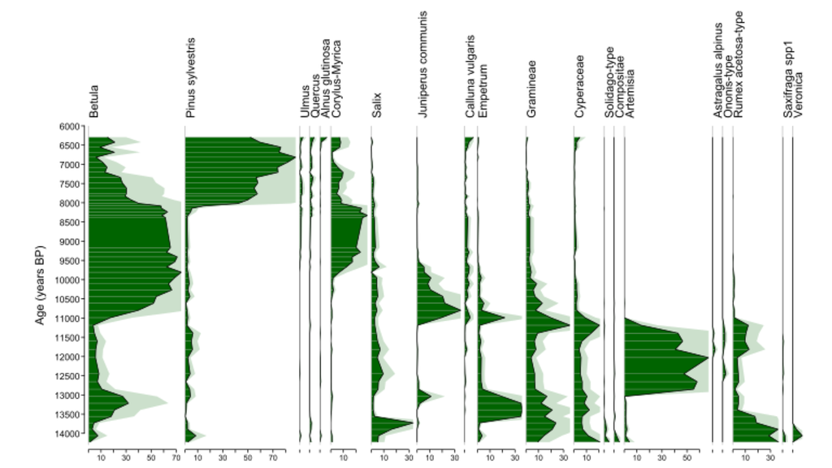

```r
cowplot::ggdraw() + cowplot::draw_image("Myplot1.svg")
```

Or save the plots to an object and combine using plot_grid:

```r
svg("Myplot2.svg", width=10, height=6) # figure dimensions in inches
riojaPlot(aber.poll, aber.chron, aber.sel,
   yvar.name="Age (years BP)",
   ymin=6000,
   ymax=14300,
   yinterval=500,
   scale.percent=TRUE,
   plot.poly=FALSE
   )
dev.off()
```

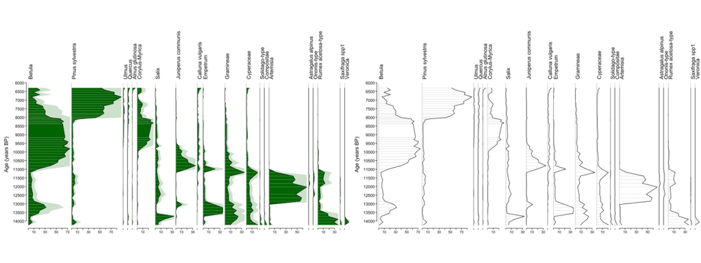

```r
p1 <- cowplot::ggdraw() + cowplot::draw_image("Myplot1.svg")
p2 <- cowplot::ggdraw() + cowplot::draw_image("Myplot2.svg")
cowplot::plot_grid(p1, p2, align="v", axis="tblr")
```

```r
file.remove("Myplot1.svg")
```

```
#> [1] TRUE
```

```r
file.remove("Myplot2.svg")
```

```
#> [1] TRUE
```

### 18. Can I use a pipe with riojaPlot

Yes, for diagrams with multiple parts you can pipe the output from one section into the next. Use function `riojaPlot2` to add additional dataset to the plot. This is just a wrapper around `riojaPlot()` that takes a `riojaPlot` object as the first argument. Here is the example from section 8 above rewritten to use the pipe.

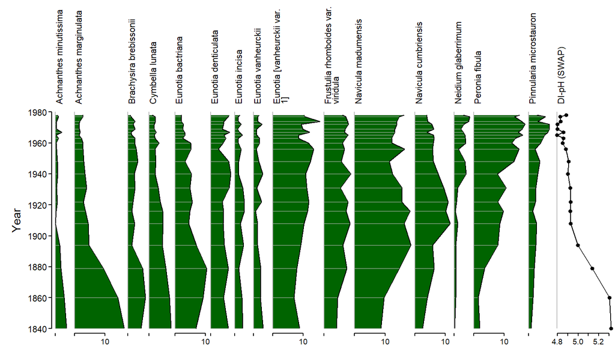

```r
riojaPlot(RLGH.diat, RLGH.chron,
          yvar.name="Year",
          scale.percent=TRUE,
          y.rev=FALSE,
          selVars=RLGH.sel,
          ymax=1980,
          xlabels=RLGH$names$TaxonName,
          cex.xlabel=0.7,
          labels.break.n=25,
          xRight=0.9) |>
  riojaPlot2(RLGH.pH, RLGH.chron[, "Year", drop=FALSE],
          scale.minmax=FALSE,
          plot.bar=FALSE,
          plot.symb=TRUE,
          symb.cex=0.6)
```

### 19. How do I cite riojaPlot in a publication

```
#>
#>   Juggins, S. (2025) riojaPlot: Stratigraphic diagrams in R, package version (0.1-21). (https://github.com/nsj3/riojaPlot).
#>
#> A BibTeX entry for LaTeX users is
#>
#>   @Manual{,
#>     title = {riojaPlot: Stratigraphic diagrams in R},
#>     author = {Steve Juggins},
#>     year = {2025},
#>     note = {R package version 0.1-21},
#>     url = {https://github.com/nsj3/riojaPlot},
#>   }
```

### 20. I get an error “Too many variables, curves will be too small”

If you try to plot too many variable in a single diagram the width of each will be too small to show in a meaningful way and riojaPlot will issue this error message. To fix this either reduce the number of variables or increase the size of the plotting window. If you want to view onscreen you can open a new plotting window with the `windows(width=10, height=5)` (on Windows) or `quartz(width=10, height=5)` (on MacOS), where width and height are in inches. Don’t forget to close the windows when finished to return plotting to the R/Rstudio plot window. If you want to save to file just use function `pdf()` or `svg()` with appropriate width / height (see FAQ 17 above).

```r
fpath <- system.file("extdata/LochChon.xlsx", package="riojaPlot")
chon <- readxl::read_excel(fpath, sheet="Diatoms")

chon.diat <- chon %>% select(-Year)
chon.year <- chon %>% select(Year)

# this will give an error
riojaPlot(chon.diat, chon.year,
          scale.percent=TRUE,
          yinterval=1,
          plot.poly=TRUE,
          plot.line=FALSE,
          plot.groups=TRUE,
          cex.xlabel=0.6,
          cex.yaxis=0.5,
          labels.italicise=TRUE,
          cex.xaxis=0.5)
```

```
#> Error in .riojaPlot2(d, yvar = yvar, y.rev = style$y.rev, scale.percent = style$scale.percent, : Too many variables, curves will be too small.
```

```r
# but this will work

svg("MyPlot.svg", width=20, height=8)
riojaPlot(chon.diat, chon.year,
          scale.percent=TRUE,
          yinterval=1,
          plot.poly=TRUE,
          plot.line=FALSE,
          plot.groups=TRUE,
          cex.xlabel=0.6,
          cex.yaxis=0.5,
          labels.italicise=TRUE,
          cex.xaxis=0.5)
dev.off()
```

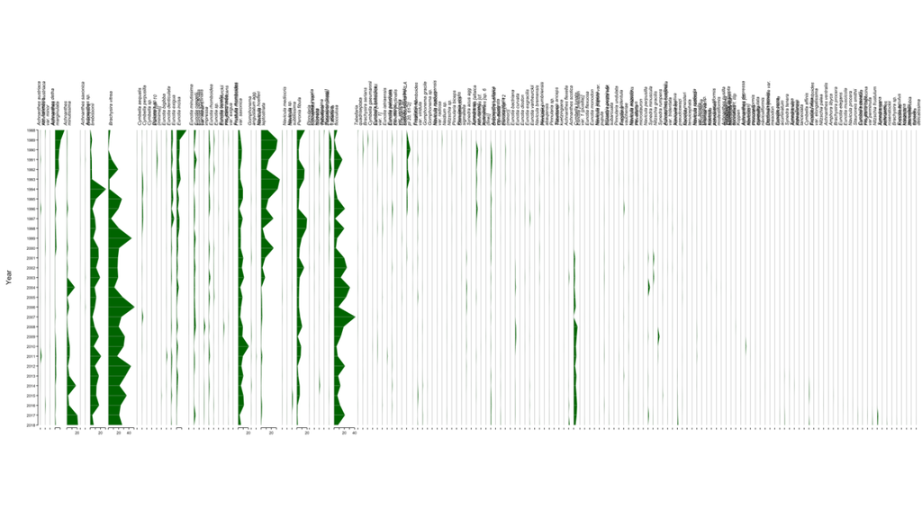

```r
cowplot::ggdraw() + cowplot::draw_image("Myplot.svg")
```

```r
file.remove("Myplot.svg")
```

```
#> [1] TRUE
```

[output not shown]

## 12. References

Allen, J.R.M. *et al*. (1999) Rapid environmental changes in southern Europe during the last glacial period. Nature, 400, 740-743.

Bennion, H. (1994) A diatom-phosphorus transfer function for shallow, eutrophic ponds in southeast England. *Hydrobiologia*, **275/276**, 391-410.

Frugone-Álvarez, M. et al. (2020) Volcanism and climate change as drivers in Holocene depositional dynamic of Laguna del Maule (Andes of central Chile - 36S). Climate of the Past, DOI 10.5194/cp-2019-147.